# Data 312 Lecture10

## Preliminaries

Before proceeding, let us run the script below:

```r
# Packages we used last time
library(tidyverse)
library(tidytext)
library(janeaustenr)
library(gutenbergr)

# New packages this week
# install.packages("igraph")
library(igraph)
# install.packages("ggraph")
library(ggraph)
```

## **Central question in text mining**

A central question in text mining and natural language processing is how to quantify what a document is about.

There is a measure or score called **tf-idf** which is a measure or score of a word’s importance to a document/body of work when examining in the context of a collection/corpus. Let us break down this concept.

One measure of how important a word to a specific body of work (e.g., Jane Austen’s *Sense & Sensibility*), may be is its *term frequency* **(tf)** to represent how frequently a word occurs.

For a body of work (e.g., book, chapter), the *term frequency* **(tf)** is formally defined as:

$$\frac{n_{word_{specific}}}{n_{word_{all}}}$$

where $n_{word_{specific}}$ = the number of a word of interest in the body of work (e.g., the number of ‘prejudice’ mentions in “*Sense & Sensibility”*) and $n_{word_{all}}$ = total words in the body of work (e.g. ”*Sense & Sensibility”)*.

There are words in a document, however, that occur many times but may not be important; in English, these are probably words like “the”, “is”, “of”, and so forth. We defined these as **stop words**. We manually removed words that are considered **stop words**. There is always subjectivity in choosing **stop words** though.

Another approach when you are comparing a body of work (e.g., book by book from Jane Austen’s work) is to look at a term’s *inverse document frequency* **(idf)**, which decreases the weight for commonly used words and increases the weight for words that are not used very much in a collection of documents.

**Real word meaning or implication:** We must use some mathematical or statistical way to penalize common words across a body of work. For example, “the” is a word that exists across the six novels, so tf (term frequency) has to be penalized.

This can be combined with term frequency to calculate a term’s *tf-idf* (the two quantities multiplied together), the frequency of a term adjusted for how rarely it is used.

The statistic **tf-idf** is intended to measure how important a word is to a document in a collection (or corpus) of documents(e.g., importance of a specific word in one novel when we are looking across a collection of novels or to one website in a collection of websites).

Let us formally defined the **idf** equation as:

$$idf(term) = ln(\frac{n_{documents}}{n_{Documents Containing Term}})$$

Examples for the Jane Austen Books: $idf('the') = ln(\frac{6}{6}) = ln(1) = 0$ because there are 6 Jane Austen books within our analysis, and the word ‘the’ appears in all 6.

Meanwhile for cry:

$idf('cry') = ln(\frac{6}{5}) = 0.1823216$

because there are 6 Jane Austen books within our analysis, and the word ‘cry’ appears in 5.

**Again:** *tf-idf* is two quantities multiplied together. So regardless of the tf value for the word ‘the’, the *tf-idf* (again multiplication) is zero because ‘the’ appeared in all six of Jane Austen’s book.

So you may think of *tf-idf* as a score to determine the importance of words in a body of work since the score is penalized more heavily the more it exist in other body of work.

## tf-idf: Applied Example

Let us revisit the published novels of Jane Austen and to first examine the term frequency before then diving into tf-idf.

```r
# Download Austen's book as austen_book then tokenize
austen_book_tidy <- austen_books() |>
  unnest_tokens(output = word, input = text)

# Visualize newly created data frame in the R env't
head(austen_book_tidy)
```

```
# A tibble: 6 × 2
  book                word
  <fct>               <chr>
1 Sense & Sensibility sense
2 Sense & Sensibility and
3 Sense & Sensibility sensibility
4 Sense & Sensibility by
5 Sense & Sensibility jane
6 Sense & Sensibility austen
```

```r
# tallies the word counts
book_words <- austen_book_tidy |>
  group_by(book, word) |>
  summarize(n = n()) |>
  arrange(desc(n))
head(book_words)
```

```
# A tibble: 6 × 3
# Groups:   book [2]
  book           word      n
  <fct>          <chr> <int>
1 Mansfield Park the    6206
2 Mansfield Park to     5475
3 Mansfield Park and    5438
4 Emma           to     5239
5 Emma           the    5201
6 Emma           and    4896
```

```r
# calculates the term frequence
book_words_scored <-  book_words |>
  bind_tf_idf(term = word, # column/variable containing terms words
              document = book, # column/variable containing collection
              n = n) # n is just the counts

head(book_words_scored, 10)
```

```
# A tibble: 10 × 6
# Groups:   book [3]
   book              word      n     tf   idf tf_idf
   <fct>             <chr> <int>  <dbl> <dbl>  <dbl>
 1 Mansfield Park    the    6206 0.0387     0      0
 2 Mansfield Park    to     5475 0.0341     0      0
 3 Mansfield Park    and    5438 0.0339     0      0
 4 Emma              to     5239 0.0325     0      0
 5 Emma              the    5201 0.0323     0      0
 6 Emma              and    4896 0.0304     0      0
 7 Mansfield Park    of     4778 0.0298     0      0
 8 Pride & Prejudice the    4331 0.0354     0      0
 9 Emma              of     4291 0.0267     0      0
10 Pride & Prejudice to     4162 0.0341     0      0
```

```r
# Identifies top 10 words for each book
top10_words <- book_words_scored |>
  group_by(book) %>%
  slice_max(tf_idf, n = 10)
# again, tf_idf and n = 10 inside slice_max() tells R that you want the top 10 for each book of entries with the highest values of tf_idf

top10_words
```

```
# A tibble: 60 × 6
# Groups:   book [6]
   book                word           n       tf   idf  tf_idf
   <fct>               <chr>      <int>    <dbl> <dbl>   <dbl>
 1 Sense & Sensibility elinor       623 0.00519   1.79 0.00931
 2 Sense & Sensibility marianne     492 0.00410   1.79 0.00735
 3 Sense & Sensibility dashwood     231 0.00193   1.79 0.00345
 4 Sense & Sensibility jennings     199 0.00166   1.79 0.00297
 5 Sense & Sensibility willoughby   181 0.00151   1.79 0.00270
 6 Sense & Sensibility brandon      119 0.000992  1.79 0.00178
 7 Sense & Sensibility ferrars      114 0.000950  1.79 0.00170
 8 Sense & Sensibility lucy         160 0.00133   1.10 0.00147
 9 Sense & Sensibility barton        89 0.000742  1.79 0.00133
10 Sense & Sensibility middleton     87 0.000725  1.79 0.00130
# ℹ 50 more rows
```

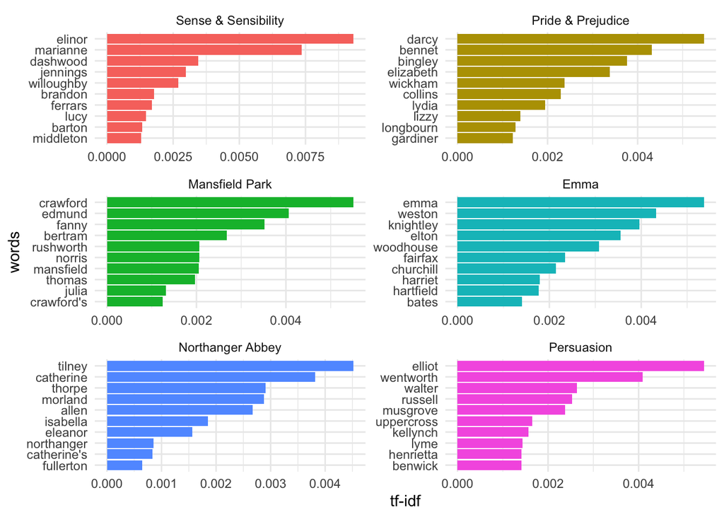

```r
# creates the plot desired similar to what we did last week
ggplot(top10_words, aes(x = tf_idf,
                        y = fct_reorder(word, tf_idf),
                        fill = book)) +
  geom_col(show.legend = FALSE) +
  facet_wrap(~book, ncol = 2, scales = "free") +
  labs(x = "tf-idf", y = "words") +
  theme_minimal()
```

## Practice 1 (20 mins)

The code chunk below downloads into R the following books into `physics_books`: [*Discourse on Floating Bodies* by Galileo Galilei](http://www.gutenberg.org/ebooks/37729), [*Relativity: The Special and General Theory* by Albert Einstein](http://www.gutenberg.org/ebooks/30155), [**Opticks : or, A treatise of the reflections, refractions, inflections and colours of light by Isaac Newton**](https://www.gutenberg.org/ebooks/33504)**, and** [Experimental Researches in Electricity, Volume 1 by Michael Faraday.](https://www.gutenberg.org/ebooks/14986)

Run the code before doing anything else so you can see a print out of `physics_books`:

```r
# Downloads books you will create a tf-idf plot for and visualizes data example
physics_books <- gutenberg_download(c(37729, 30155, 33504, 14986), meta_fields = "author")
```

```
Determining mirror for Project Gutenberg from https://www.gutenberg.org/robot/harvest
```

```
Using mirror http://aleph.gutenberg.org
```

```r
head(physics_books)
```

```
# A tibble: 6 × 3
  gutenberg_id text                                     author
         <int> <chr>                                    <chr>
1        14986 "EXPERIMENTAL RESEARCHES IN ELECTRICITY" Faraday, Michael
2        14986 ""                                       Faraday, Michael
3        14986 "by"                                     Faraday, Michael
4        14986 ""                                       Faraday, Michael
5        14986 "MICHAEL FARADAY, D.C.L. F.R.S."         Faraday, Michael
6        14986 ""                                       Faraday, Michael
```

Your goal is to create a tf-idf plot broken down by `author` in the R chunks provided below. Complete the following code after following commented guidelines.

```r
# Tokenize physics_books accordingly and save the resulting table/df into the R env't
# then use head() to visualize tokenized data
physics_tidy <- physics_books |>
  unnest_tokens(word, text)
head(physics_tidy)
```

```
# A tibble: 6 × 3
  gutenberg_id author           word
         <int> <chr>            <chr>
1        14986 Faraday, Michael experimental
2        14986 Faraday, Michael researches
3        14986 Faraday, Michael in
4        14986 Faraday, Michael electricity
5        14986 Faraday, Michael by
6        14986 Faraday, Michael michael
```

```r
# Create a table that tallies the word counts by author and word into the R env't then use head() to visualize new table
physics_tallied <- physics_tidy |>
  group_by(author, word) |>
  summarise(n = n())
head(physics_tallied)
```

```
# A tibble: 6 × 3
# Groups:   author [1]
  author           word      n
  <chr>            <chr> <int>
1 Einstein, Albert 0        13
2 Einstein, Albert 1        21
3 Einstein, Albert 1.08      1
4 Einstein, Albert 1.7       1
5 Einstein, Albert 10        4
6 Einstein, Albert 1027      1
```

```r
# Use bind_tf_idf() and save new table/data into the R env't
# then use head() to visualize new table
physics_scored <- physics_tallied |>
  bind_tf_idf(term = word,
              document = author,
              n = n)
head(physics_scored)
```

```
# A tibble: 6 × 6
# Groups:   author [1]
  author           word      n        tf   idf    tf_idf
  <chr>            <chr> <int>     <dbl> <dbl>     <dbl>
1 Einstein, Albert 0        13 0.000413  0     0
2 Einstein, Albert 1        21 0.000668  0     0
3 Einstein, Albert 1.08      1 0.0000318 1.39  0.0000441
4 Einstein, Albert 1.7       1 0.0000318 1.39  0.0000441
5 Einstein, Albert 10        4 0.000127  0     0
6 Einstein, Albert 1027      1 0.0000318 0.693 0.0000220
```

```r
# Identifies top 15 words for each book using slice_max() and save new table/data into the R env't
# then use head() to visualize new table
top15_words <- physics_scored |>
  group_by(author) |>
  slice_max(tf_idf, n = 15)
head(top10_words)
```

```
# A tibble: 6 × 6
# Groups:   book [1]
  book                word           n       tf   idf  tf_idf
  <fct>               <chr>      <int>    <dbl> <dbl>   <dbl>
1 Sense & Sensibility elinor       623 0.00519   1.79 0.00931
2 Sense & Sensibility marianne     492 0.00410   1.79 0.00735
3 Sense & Sensibility dashwood     231 0.00193   1.79 0.00345
4 Sense & Sensibility jennings     199 0.00166   1.79 0.00297
5 Sense & Sensibility willoughby   181 0.00151   1.79 0.00270
6 Sense & Sensibility brandon      119 0.000992  1.79 0.00178
```

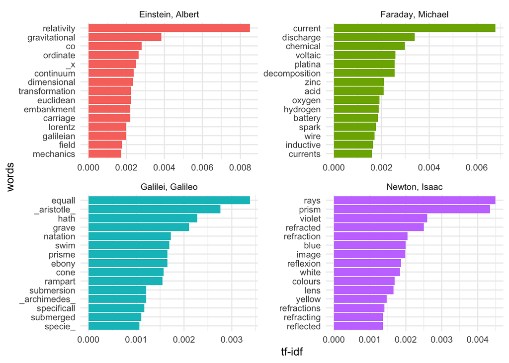

```r
# Use ggplot() and geom_col() to plot your tf_idf plot
ggplot(top15_words, aes(tf_idf, fct_reorder(word, tf_idf), fill = author)) +
  geom_col(show.legend = FALSE) +
  facet_wrap(~author, ncol = 2, scales = "free") +
  labs(x = "tf-idf", y = "words") +
  theme_minimal()
```

## n-grams and word-pairings

So far we’ve considered words as individual units, and considered their relationships to sentiments or to documents.

However, many interesting text analyses are based on the relationships between words, whether examining which words tend to follow others immediately, or that tend to co-occur within the same documents.

In this lecture/lab section, we’ll explore some of the methods tidytext offers for calculating and visualizing relationships between words in your text dataset.

This includes the `token = "ngrams"` argument in `unnest_tokens()`, which tokenizes by pairs of adjacent words rather than by individual ones.

## Bigrams: Word Pairings

When n = 2 for ngrams, we are looking into word pairings (also known as bigrams).

This data structure below is still a variation of the tidy text format. It is structured as one-token-per-row but each token now represents a bigram.

```r
austen_pair_tidy <- austen_books() |>
  unnest_tokens(bigram, text, token = "ngrams", n = 2) |>
  filter(!is.na(bigram)) # this removes rows with empty bigram fields

head(austen_pair_tidy, 10)
```

```
# A tibble: 10 × 2
   book                bigram
   <fct>               <chr>
 1 Sense & Sensibility sense and
 2 Sense & Sensibility and sensibility
 3 Sense & Sensibility by jane
 4 Sense & Sensibility jane austen
 5 Sense & Sensibility chapter 1
 6 Sense & Sensibility the family
 7 Sense & Sensibility family of
 8 Sense & Sensibility of dashwood
 9 Sense & Sensibility dashwood had
10 Sense & Sensibility had long
```

Let us do a quick tally of bigram pairs and see which ones are the most common (just see top 10):

```r
austen_pair_tidy |>
  group_by(book, bigram) |>
  summarise(n = n()) |>
  arrange(desc(n)) |>
  head(10)
```

```
# A tibble: 10 × 3
# Groups:   book [4]
   book                bigram     n
   <fct>               <chr>  <int>
 1 Mansfield Park      of the   712
 2 Mansfield Park      to be    612
 3 Emma                to be    586
 4 Mansfield Park      in the   533
 5 Emma                of the   529
 6 Pride & Prejudice   of the   439
 7 Emma                it was   430
 8 Pride & Prejudice   to be    422
 9 Sense & Sensibility to be    418
10 Emma                in the   416
```

As one might expect, a lot of the most common bigrams are pairs of common (uninteresting) words, such as `of the` and `to be`: what we call “stop-words”.

This is a useful time to use tidyr’s [`separate()`](https://tidyr.tidyverse.org/reference/separate.html), which splits a column into multiple based on a delimiter (a character or set of characters that is guaranteed to split/chop a body of text).

This lets us separate it into two columns, “word1” and “word2”, at which point we can remove cases where either word is a stop-word. tidyr is part of the tidyverse package, so this is loaded via library(tidyverse).

```r
bigram_separated <- austen_pair_tidy |>
  separate(col = bigram,
           into = c("word1", "word2"),
           sep = " ")
# col: is the column/variable to separate
# into: lets R know that you want the new columns to be named word1, word2
# sep = " ": lets R know that bigram words is seperated by white space,
# it will use this white space to cut bigram into word1 and word2

head(bigram_separated, 10)
```

```
# A tibble: 10 × 3
   book                word1    word2
   <fct>               <chr>    <chr>
 1 Sense & Sensibility sense    and
 2 Sense & Sensibility and      sensibility
 3 Sense & Sensibility by       jane
 4 Sense & Sensibility jane     austen
 5 Sense & Sensibility chapter  1
 6 Sense & Sensibility the      family
 7 Sense & Sensibility family   of
 8 Sense & Sensibility of       dashwood
 9 Sense & Sensibility dashwood had
10 Sense & Sensibility had      long
```

```r
# loads stop_words into your R env't
data("stop_words")

# if the bigram pair has a stop word, it gets removed
bigrams_filtered <- bigram_separated |>
  filter(!word1 %in% stop_words$word) |>
  filter(!word2 %in% stop_words$word)

head(bigrams_filtered)
```

```
# A tibble: 6 × 3
  book                word1       word2
  <fct>               <chr>       <chr>
1 Sense & Sensibility jane        austen
2 Sense & Sensibility chapter     1
3 Sense & Sensibility norland     park
4 Sense & Sensibility surrounding acquaintance
5 Sense & Sensibility late        owner
6 Sense & Sensibility advanced    age
```

```r
bigrams_filtered_counts <- bigrams_filtered |>
  group_by(book, word1, word2) |>
  summarise(n = n()) |>
  arrange(desc(n))
head(bigrams_filtered_counts, 10)
```

```
# A tibble: 10 × 4
# Groups:   book, word1 [9]
   book                word1   word2         n
   <fct>               <chr>   <chr>     <int>
 1 Mansfield Park      sir     thomas      266
 2 Mansfield Park      miss    crawford    196
 3 Emma                miss    woodhouse   143
 4 Persuasion          captain wentworth   143
 5 Emma                frank   churchill   114
 6 Persuasion          lady    russell     110
 7 Persuasion          sir     walter      108
 8 Mansfield Park      lady    bertram     101
 9 Emma                miss    fairfax      98
10 Sense & Sensibility colonel brandon      96
```

## Bigram can be useful for context

This requires some creativity for usage. Some examples below to follow:

For example, if you are interested in mentions of specific street names, you can use the code below to determine most common streets mentioned:

```r
bigrams_filtered_counts |>
  filter(word2 == "street") |>
  group_by(book, word1, word2) |>
  summarise(n = n()) |>
  arrange(-n) # again -n is the same as desc(n)
```

```
# A tibble: 33 × 4
# Groups:   book, word1 [33]
   book                word1       word2      n
   <fct>               <chr>       <chr>  <int>
 1 Sense & Sensibility berkeley    street     1
 2 Sense & Sensibility bond        street     1
 3 Sense & Sensibility conduit     street     1
 4 Sense & Sensibility harley      street     1
 5 Sense & Sensibility james       street     1
 6 Sense & Sensibility park        street     1
 7 Sense & Sensibility sackville   street     1
 8 Pride & Prejudice   edward      street     1
 9 Pride & Prejudice   gracechurch street     1
10 Pride & Prejudice   grosvenor   street     1
# ℹ 23 more rows
```

Here’s another example where we look at how beauty is referenced in bigram pairs (when beauty is either in word1 or word2):

```r
bigrams_filtered_counts |>
  filter(word1 == "beauty" | word2 == "beauty") |>
  group_by(book, word1, word2) |>
  summarise(n = n())
```

```
# A tibble: 38 × 4
# Groups:   book, word1 [33]
   book                word1        word2         n
   <fct>               <chr>        <chr>     <int>
 1 Sense & Sensibility beauty       courting      1
 2 Sense & Sensibility considerable beauty        1
 3 Sense & Sensibility manly        beauty        1
 4 Sense & Sensibility picturesque  beauty        1
 5 Sense & Sensibility rising       beauty        1
 6 Sense & Sensibility unites       beauty        1
 7 Sense & Sensibility youth        beauty        1
 8 Pride & Prejudice   beauty       elegance      1
 9 Pride & Prejudice   beauty       miss          1
10 Pride & Prejudice   beauty       succeeded     1
# ℹ 28 more rows
```

Here’s another example where we look at how Eleanor (character from Northanger Abbey) is referenced:

```r
bigrams_filtered_counts |>
  filter(word1 == "eleanor" | word2 == "eleanor") |>
  group_by(book, word1, word2) |>
  summarise(n = n()) |>
  arrange(-n) # again -n is the same as desc(n)
```

```
# A tibble: 29 × 4
# Groups:   book, word1 [18]
   book             word1      word2       n
   <fct>            <chr>      <chr>   <int>
 1 Northanger Abbey added      eleanor     1
 2 Northanger Abbey addressing eleanor     1
 3 Northanger Abbey dear       eleanor     1
 4 Northanger Abbey distressed eleanor     1
 5 Northanger Abbey door       eleanor     1
 6 Northanger Abbey eleanor    brought     1
 7 Northanger Abbey eleanor    coldly      1
 8 Northanger Abbey eleanor    cried       1
 9 Northanger Abbey eleanor    entered     1
10 Northanger Abbey eleanor    leave       1
# ℹ 19 more rows
```

## Practice 2 (20 mins)

Run the code before doing anything else so you can see a print out of `newton_book`:

```r
# Downloads book from newton
newton_book <- gutenberg_download(c(33504), meta_fields = "author")
head(newton_book)
```

```
# A tibble: 6 × 3
  gutenberg_id text       author
         <int> <chr>      <chr>
1        33504 "OPTICKS:" Newton, Isaac
2        33504 ""         Newton, Isaac
3        33504 "OR, A"    Newton, Isaac
4        33504 ""         Newton, Isaac
5        33504 "TREATISE" Newton, Isaac
6        33504 ""         Newton, Isaac
```

Using `newton_book` and the R chunk provided below, create then print using `head()` a bigram word count table that excludes stop words. Name this data frame however you want.

```r
# Task 2.a. (there is another task in another code chunk)
data("stop_words")

bigram_tbl_newton <- newton_book |>
  unnest_tokens(output = bigram, input = text, token = "ngrams", n = 2) |>
  filter(!is.na(bigram)) |>
  separate(col = "bigram", into = c("word1", "word2"), sep = " ") |>
  filter(!word1 %in% stop_words$word) |>
  filter(!word2 %in% stop_words$word) |>
  group_by(author, word1, word2) |>
  summarise(n = n()) |>
  arrange(-n)
head(bigram_tbl_newton)
```

```
# A tibble: 6 × 4
# Groups:   author, word1 [5]
  author        word1        word2     n
  <chr>         <chr>        <chr> <int>
1 Newton, Isaac refrangible  rays     75
2 Newton, Isaac 1            2        63
3 Newton, Isaac illustration fig      57
4 Newton, Isaac 2            3        42
5 Newton, Isaac sun's        light    41
6 Newton, Isaac 1            3        36
```

Using the data frame you created above and the R chunk provided below, show a subset where “rays” is mentioned in either word1 or word2 to get context around this word:

```r
# Task 2.b.
bigram_tbl_newton |>
  filter(word1 %in% "rays" | word2 %in% "rays")
```

```
# A tibble: 91 × 4
# Groups:   author, word1 [28]
   author        word1         word2     n
   <chr>         <chr>         <chr> <int>
 1 Newton, Isaac refrangible   rays     75
 2 Newton, Isaac incident      rays     16
 3 Newton, Isaac heterogeneous rays      9
 4 Newton, Isaac refracted     rays      9
 5 Newton, Isaac rays          fall      7
 6 Newton, Isaac emergent      rays      6
 7 Newton, Isaac rays          flow      6
 8 Newton, Isaac rays          pass      5
 9 Newton, Isaac sun's         rays      5
10 Newton, Isaac perpendicular rays      4
# ℹ 81 more rows
```

## Trigrams: Three-Word Pairings (n=3)

Similar to n=2 (bigrams) with some minor tweaks (e.g., n = 3, addition of “word3”, etc).

Part of the reason why I have this code is to show you a consolidated code of combining what we did for bigram but in one code that uses pipes.

This is the way the book codes but if you dislike this code that does too much, follow broken down code structure for you did for bigram above.

I generally don’t recommend you code this way (the way your book and the code below codes) if you’re a beginner programmer. Otherwise, you are more than welcome to follow this structure:

```r
# loads stop_words into the R env't
data("stop_words")

# consolidated code to create clean trigram counts
austen_trigram_counts <- austen_books() |>
  unnest_tokens(trigram, text, token = "ngrams", n = 3) |>
  filter(!is.na(trigram)) |>
  separate(col = trigram,
           into = c("word1", "word2", "word3"),
           sep = " ") |>
  filter(!word1 %in% stop_words$word) |>
  filter(!word2 %in% stop_words$word) |>
  filter(!word3 %in% stop_words$word) |>
  group_by(book, word1, word2, word3) |>
  summarise(n = n()) |>
  arrange(desc(n))
head(austen_trigram_counts, 10)
```

```
# A tibble: 10 × 5
# Groups:   book, word1, word2 [10]
   book              word1     word2     word3         n
   <fct>             <chr>     <chr>     <chr>     <int>
 1 Emma              dear      miss      woodhouse    20
 2 Pride & Prejudice miss      de        bourgh       17
 3 Pride & Prejudice lady      catherine de           11
 4 Emma              poor      miss      taylor       11
 5 Persuasion        sir       walter    elliot       10
 6 Pride & Prejudice catherine de        bourgh        9
 7 Mansfield Park    dear      sir       thomas        8
 8 Pride & Prejudice sir       william   lucas         7
 9 Mansfield Park    replied   miss      crawford      7
10 Persuasion        miss      anne      elliot        6
```

## ngram and tf-idf

tf-idf again is a measure of importance of a word to a document/body of work in a collection/corpus.

Let us again create a tidy data frame of the Jane Austen novels with bigrams:

```r
austen_pair_tidy <- austen_books() |>
  unnest_tokens(bigram, text, token = "ngrams", n = 2) |>
  filter(!is.na(bigram)) # this removes rows with empty bigram fields

head(austen_pair_tidy, 10)
```

```
# A tibble: 10 × 2
   book                bigram
   <fct>               <chr>
 1 Sense & Sensibility sense and
 2 Sense & Sensibility and sensibility
 3 Sense & Sensibility by jane
 4 Sense & Sensibility jane austen
 5 Sense & Sensibility chapter 1
 6 Sense & Sensibility the family
 7 Sense & Sensibility family of
 8 Sense & Sensibility of dashwood
 9 Sense & Sensibility dashwood had
10 Sense & Sensibility had long
```

```r
# Creates the top 10 words using tf_idf score for each book
austen_bigram_tf_idf <- austen_pair_tidy |>
  group_by(book, bigram) |>
  summarise(n = n()) |>
  bind_tf_idf(term = bigram, document = book, n = n) |>
  group_by(book) |>
  slice_max(tf_idf, n = 10)
austen_bigram_tf_idf
```

```
# A tibble: 60 × 6
# Groups:   book [6]
   book                bigram              n       tf   idf   tf_idf
   <fct>               <chr>           <int>    <dbl> <dbl>    <dbl>
 1 Sense & Sensibility mrs jennings      185 0.00169   1.79 0.00303
 2 Sense & Sensibility mrs dashwood       97 0.000887  1.79 0.00159
 3 Sense & Sensibility colonel brandon    96 0.000878  1.79 0.00157
 4 Sense & Sensibility sir john           94 0.000860  1.79 0.00154
 5 Sense & Sensibility lady middleton     75 0.000686  1.79 0.00123
 6 Sense & Sensibility mrs ferrars        57 0.000521  1.79 0.000934
 7 Sense & Sensibility said elinor        56 0.000512  1.79 0.000917
 8 Sense & Sensibility miss dashwood      55 0.000503  1.79 0.000901
 9 Sense & Sensibility and elinor         52 0.000475  1.79 0.000852
10 Sense & Sensibility marianne was       45 0.000411  1.79 0.000737
# ℹ 50 more rows
```

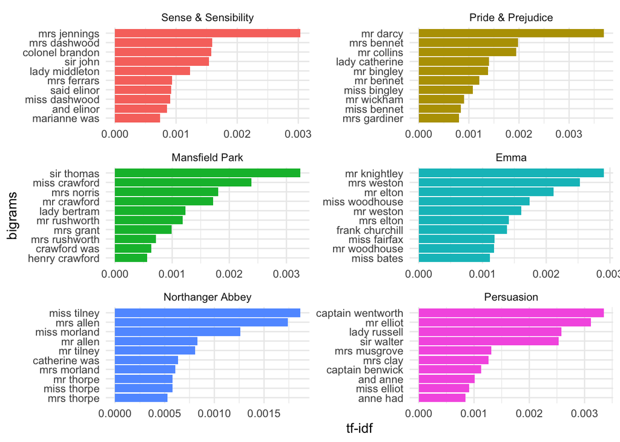

```r
# Creates the tf-idf plot
ggplot(austen_bigram_tf_idf, aes(x = tf_idf,
                                 y = fct_reorder(bigram, tf_idf),
                                 fill = book)) +
  geom_col(show.legend = FALSE) +
  facet_wrap(~book, ncol = 2, scales = "free") +
  labs(x = "tf-idf", y = "bigrams") +
  theme_minimal()
```

## Practice 3 (15 mins)

The code chunk below downloads into R the following books as `physics_books`: [*Discourse on Floating Bodies* by Galileo Galilei](http://www.gutenberg.org/ebooks/37729), [*Relativity: The Special and General Theory* by Albert Einstein](http://www.gutenberg.org/ebooks/30155), [**Opticks : or, A treatise of the reflections, refractions, inflections and colours of light by Isaac Newton**](https://www.gutenberg.org/ebooks/33504)**, and** [Experimental Researches in Electricity, Volume 1 by Michael Faraday.](https://www.gutenberg.org/ebooks/14986)

Run the code before doing anything else so you can see a print out of `physics_books`:

```r
# Downloads books you will create a tf-idf plot for and visualizes data example
physics_books <- gutenberg_download(c(37729, 30155, 33504, 14986), meta_fields = "author")
head(physics_books)
```

```
# A tibble: 6 × 3
  gutenberg_id text                                     author
         <int> <chr>                                    <chr>
1        14986 "EXPERIMENTAL RESEARCHES IN ELECTRICITY" Faraday, Michael
2        14986 ""                                       Faraday, Michael
3        14986 "by"                                     Faraday, Michael
4        14986 ""                                       Faraday, Michael
5        14986 "MICHAEL FARADAY, D.C.L. F.R.S."         Faraday, Michael
6        14986 ""                                       Faraday, Michael
```

Your ultimate goal is to create a top-15 **bigram tf-idf plot** broken down by `author` in the R chunks provided below:

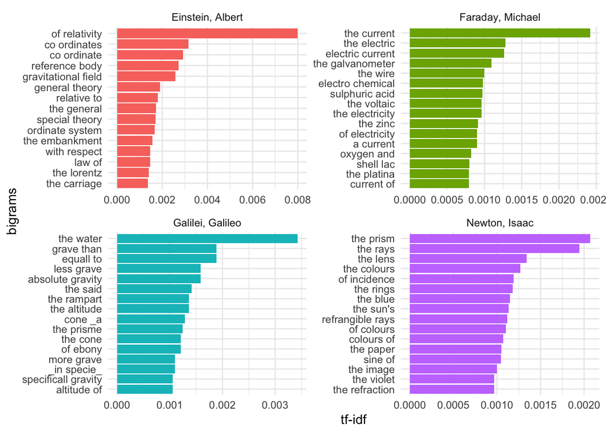

```r
# Place your code below
physics_tidy <- physics_books |>
  unnest_tokens(bigram, text, token = "ngrams", n = 2) |>
  filter(!is.na(bigram)) # this removes rows with empty bigram fields

physics_tidy_tf_idf <- physics_tidy |>
  group_by(author, bigram) |>
  summarise(n = n()) |>
  bind_tf_idf(term = bigram, document = author, n = n) |>
  group_by(author) |>
  slice_max(tf_idf, n = 15)
ggplot(physics_tidy_tf_idf, aes(x = tf_idf, y = fct_reorder(bigram, tf_idf), fill = author)) +
  geom_col(show.legend = FALSE) +
  facet_wrap(~author, ncol = 2, scales = "free") +
  labs(x = "tf-idf", y = "bigrams") +
  theme_minimal()
```

## Plotting bigraph using igraph and ggraph packages

Revisit earlier code but inside one R chunk to create `bigrams_filtered` but in this example, we don’t keep the book column (we are interested in the overall word counts):

```r
# creates the tidy text bigram table
austen_pair_counts <- austen_books() |>
  unnest_tokens(bigram, text, token = "ngrams", n = 2) |>
  filter(!is.na(bigram))
head(austen_pair_counts)
```

```
# A tibble: 6 × 2
  book                bigram
  <fct>               <chr>
1 Sense & Sensibility sense and
2 Sense & Sensibility and sensibility
3 Sense & Sensibility by jane
4 Sense & Sensibility jane austen
5 Sense & Sensibility chapter 1
6 Sense & Sensibility the family
```

```r
# seperates the bigram column into word1 and word2,
# creates a word count afterwards
bigram_separated <- austen_pair_tidy |>
  separate(col = bigram,
           into = c("word1", "word2"),
           sep = " ") |>
  group_by(word1, word2) |>
  summarise(n = n())
head(bigram_separated)
```

```
# A tibble: 6 × 3
# Groups:   word1 [4]
  word1  word2      n
  <chr>  <chr>  <int>
1 1      1760       1
2 1      1785       1
3 1      ends       1
4 10     pounds     3
5 10,000 l          2
6 14th   for        1
```

```r
# loads stop_words into your R env't
data("stop_words")

# if the bigram pair has a stop word, it gets removed
bigrams_filtered <- bigram_separated |>
  filter(!word1 %in% stop_words$word) |>
  filter(!word2 %in% stop_words$word)

head(bigrams_filtered, 10)
```

```
# A tibble: 10 × 3
# Groups:   word1 [9]
   word1 word2         n
   <chr> <chr>     <int>
 1 1     1760          1
 2 1     1785          1
 3 10    pounds        3
 4 15    1784          1
 5 15th  october       1
 6 16    1810          1
 7 1760  married       1
 8 1784  elizabeth     1
 9 1785  anne          1
10 1789  mary          1
```

Suppose we want to plot what is called a graph or network plot that shows connectivity of words. Due to limited space, we need to be selective for word pairs that appear a lot only (cut off is subjective and you may need to play around with the cut off) to highlight word pairs that are prominent.

```r
bigrams_graph <- bigrams_filtered |>
  filter(n > 35) |>
  graph_from_data_frame()
# graph_from_data_frame() transfers from data frame into igraph's network format
# IMPORTANT: make sure word1 and word2 are always the first two columns of the data frame or table before using graph_from_data_frame()

# shows you some basic information about the igraph data
bigrams_graph
```

```
IGRAPH 18a39e7 DN-- 40 33 --
+ attr: name (v/c), n (e/n)
+ edges from 18a39e7 (vertex names):
 [1] captain->benwick    captain->wentworth  colonel->brandon
 [4] dear   ->miss       dr     ->grant      frank  ->churchill
 [7] henry  ->crawford   jane   ->fairfax    john   ->knightley
[10] lady   ->bertram    lady   ->catherine  lady   ->middleton
[13] lady   ->russell    miss   ->bates      miss   ->bennet
[16] miss   ->bertram    miss   ->bingley    miss   ->crawford
[19] miss   ->crawford's miss   ->dashwood   miss   ->elliot
[22] miss   ->fairfax    miss   ->morland    miss   ->price
+ ... omitted several edges
```

Now that we have `bigrams_graph` which is a igraph-formatted data after using igraph’s `graph_from_data_frame()`, we should use the following code:

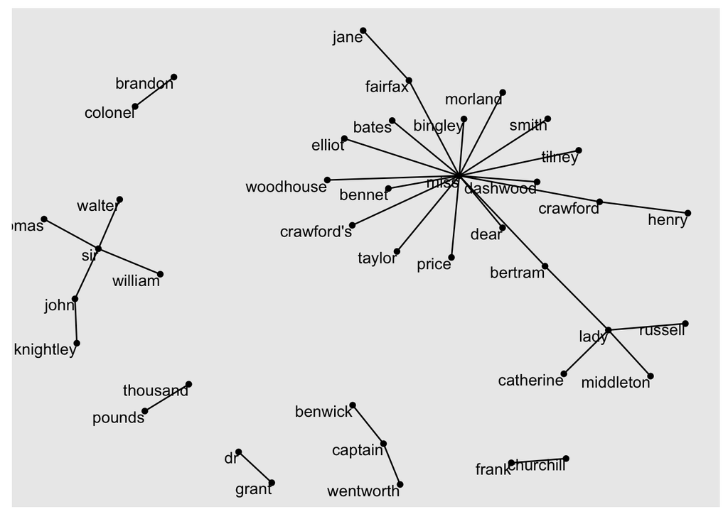

```r
# this code makes sure the graph is reproducible since ggraph applies 'randomness' in the creation of graph (i.e., not including set.seed() leads to ggraph creating unique graphs every single time you run the code)
# place any integer inside and if you don't like the graph, change it
set.seed(120312)

ggraph(bigrams_graph, layout = "fr") +
  geom_edge_link() +
  geom_node_point() +
  geom_node_text(aes(label = name), vjust = 1, hjust = 1)
```

Some sample customization you can implement to made the bare-bones graph or network plot look nicer (again, if you don’t like the current arrange of your plot, change the number within `set.seed()`. When you have time, play around some of the numbers in the customization provided to see their impact!

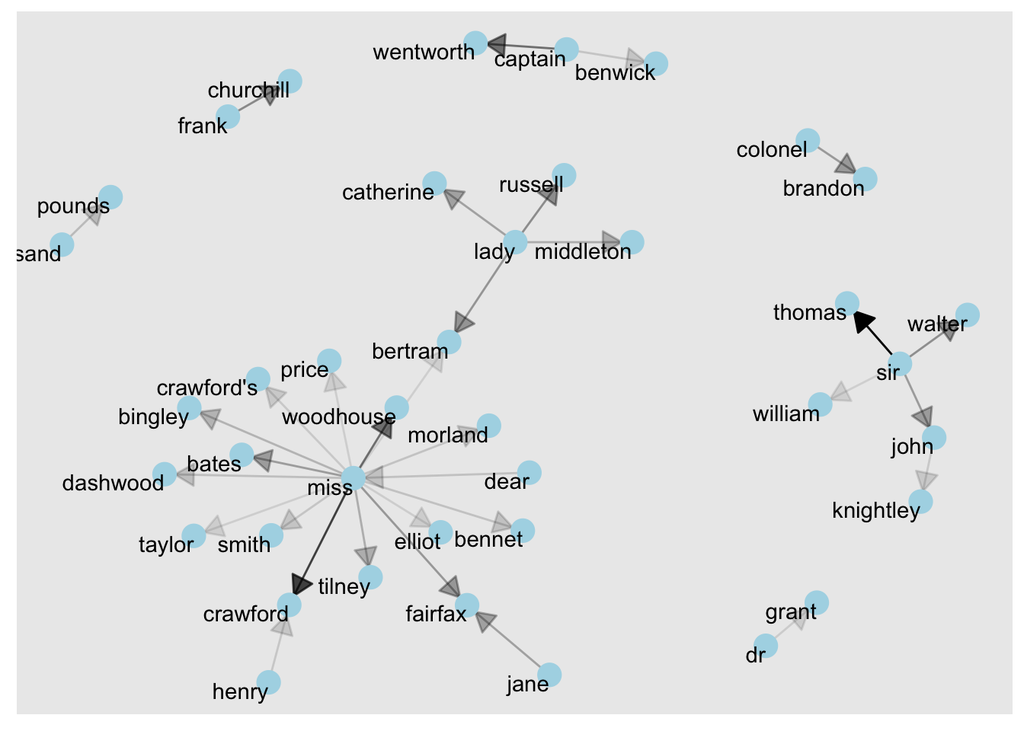

```r
set.seed(12313)

ggraph(bigrams_graph, layout = "fr") +
  geom_edge_link(aes(edge_alpha = n),
                 show.legend = FALSE,
                 end_cap = circle(.07, 'inches'),
                 arrow = grid::arrow(type = "closed",
                                      length = unit(.15, "inches"))) +
  geom_node_point(color = "lightblue", size = 5) +
  geom_node_text(aes(label = name), vjust = 1, hjust = 1)
```

## Practice 4 (15 mins)

Using `newton_book` from Practice 2, create a bigraph graph/network plot using both `graph_from_data_frame()` and `ggraph()` … feel free to pick any cut off you like for `filter()` (play around with the cut off thresholder!):

```r
# Place your code below
```